# Home work 1:

## Using Cluster Analysis (K-Means & HAC) and Decision Tree induction algorithm on a weather forecast problem. It is a binary classification problem to predict whether or not a location will get rain the next day.

Dataset Information (Weather Forecast Training.csv):

• Location: The location name of the weather station

• MinTemp: The minimum temperature in degrees celsius

• MaxTemp: The maximum temperature in degrees celsius

• Rainfall: The amount of rainfall recorded for the day in mm

• Evaporation: The so-called Class A pan evaporation (mm) in the 24 hours to 9am

• Sunshine: The number of hours of bright sunshine in the day.

• WindGustDir: The direction of the strongest wind gust in the 24 hours to midnight

• WindGustSpeed: The speed (km/h) of the strongest wind gust in the 24 hours to midnight

• WindDir: Direction of the wind

• WindSpeed: Wind speed (km/hr) averaged over 10 minutes

• Humidity: Humidity (percent)

• Pressure: Atmospheric pressure (hpa) reduced to mean sea level

• Cloud: Fraction of sky obscured by cloud This is measured in “oktas”, which are a unit of eigths. It records how many eigths of the sky are obscured by cloud. A 0 measure indicates completely clear sky whilst an 8 indicates that it is completely overcast.

• Temp: Temperature (degrees C)

• RainTodayBoolean: 1 if precipitation (mm) in the 24 hours to 9am exceeds 1mm, otherwise 0

• RainTomorrow: The target variable. Did it rain tomorrow?

### Import Libraries

```python
import numpy as np
import pandas as pd
from pandas import DataFrame, Series
import seaborn as sns
import matplotlib.pyplot as plt
from fancyimpute import IterativeImputer
from scipy import stats
from sklearn import preprocessing
from scipy.spatial import distance_matrix
from sklearn.cluster import KMeans
from sklearn.model_selection import train_test_split, GridSearchCV, cross_val_score, cross_validate, ShuffleSplit, LeaveOneOut
from sklearn import metrics
from sklearn.metrics import accuracy_score,f1_score,confusion_matrix,precision_score,classification_report,recall_score,roc_curve,roc_auc_score
from sklearn.tree import DecisionTreeClassifier
from sklearn.cluster import AgglomerativeClustering
from sklearn.preprocessing import MinMaxScaler
from scipy.cluster.hierarchy import dendrogram
from sklearn import datasets
from sklearn import tree
```

### Reading training and test data

```python
df = pd.read_csv('Weather Forecast Training.csv')
test_df = pd.read_csv('Weather Forecast Testing.csv')
```

```python
df.head()
```

|  | Location | MinTemp | MaxTemp | Rainfall | Evaporation | Sunshine | WindGustDir | WindGustSpeed | WindDir | WindSpeed | Humidity | Pressure | Cloud | Temp | RainToday | RainTomorrow |
| --- | --- | --- | --- | --- | --- | --- | --- | --- | --- | --- | --- | --- | --- | --- | --- | --- |
| 0 | NorahHead | 18.9 | 23.7 | 0.0 | NaN | NaN | SSE | 41.0 | SSE | 28.0 | 55.0 | 1026.0 | NaN | 22.4 | No | Yes |
| 1 | Nuriootpa | 11.1 | 20.8 | 0.0 | 4.8 | 8.3 | W | 39.0 | WSW | 26.0 | 48.0 | 1014.4 | 7.0 | 19.5 | No | No |
| 2 | GoldCoast | 15.9 | 19.5 | 17.6 | NaN | NaN | SE | 44.0 | SW | 9.0 | 99.0 | 1028.5 | NaN | 17.8 | Yes | Yes |
| 3 | Bendigo | 0.0 | 14.9 | 0.0 | NaN | NaN | WSW | 35.0 | WNW | 19.0 | 55.0 | 1023.0 | 4.0 | 14.2 | No | Yes |
| 4 | Walpole | 9.1 | 22.7 | 0.0 | NaN | NaN | NNE | 41.0 | ESE | 7.0 | 40.0 | 1027.1 | NaN | 22.5 | No | No |

```python
# Checking data type
df.dtypes
```

```
Location          object
MinTemp          float64
MaxTemp          float64
Rainfall         float64
Evaporation      float64
Sunshine         float64
WindGustDir       object
WindGustSpeed    float64
WindDir           object
WindSpeed        float64
Humidity         float64
Pressure         float64
Cloud            float64
Temp             float64
RainToday         object
RainTomorrow      object
dtype: object
```

## Data Pre-processing & Exploratory Data Analysis

### 1) Remove irrelevant columns

### Finding missing values in training data to impute values or if so many values are missing will delete the column.

```python
# Check for % of missing values in training data
percent_missing = df.isnull().sum() * 100 / len(df)
print(percent_missing)
```

```
Location          0.000000
MinTemp           0.546385
MaxTemp           0.248182
Rainfall          1.437146
Evaporation      43.389511
Sunshine         47.856786
WindGustDir       6.922159
WindGustSpeed     6.870214
WindDir           2.910847
WindSpeed         1.970064
Humidity          2.749240
Pressure          9.746431
Cloud            38.727923
Temp              2.045096
RainToday         1.437146
RainTomorrow      0.000000
dtype: float64
```

```python
# Check for % of missing values in testing data
percent_missing = test_df.isnull().sum() * 100 / len(test_df)
print(percent_missing)
```

```
ID                0.000000
Location          0.000000
MinTemp           0.361705
MaxTemp           0.138525
Rainfall          1.239033
Evaporation      42.450362
Sunshine         46.898569
WindGustDir       7.149454
WindGustSpeed     7.080191
WindDir           2.978298
WindSpeed         2.008619
Humidity          2.685855
Pressure          9.950746
Cloud            38.633215
Temp              2.054795
RainToday         1.239033
dtype: float64
```

#### Deleting 3 attributes from training and test data. Evaporation, Sunshine, cloud contain more than 38.6% missing values.

```python
del df['Evaporation']
del df['Sunshine']
del df['Cloud']


del test_df['Evaporation']
del test_df['Sunshine']
del test_df['Cloud']
```

#### 2) Handling outliers

Producing boxplots of all of our numerical attributes against the target variable 'RainTomorrow' and attributes will be deleted and modified to the 5th and the 95th % value.

#### Below, we have boxplots of all of our numerical attributes against the target variable i.e. RainTomorrow.

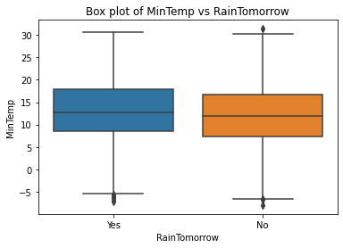

```python
# Boxplot of MinTemp attribute vs target attribute RainTomorrow
sns.boxplot(y="MinTemp", x="RainTomorrow", data=df)
plt.title("Box plot of MinTemp vs RainTomorrow")
```

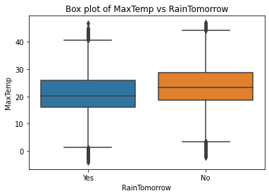

```python
# Boxplot of MaxTemp attribute vs target attribute RainTomorrow
sns.boxplot(y="MaxTemp", x="RainTomorrow", data=df)
plt.title("Box plot of MaxTemp vs RainTomorrow")
```

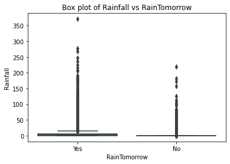

```python
# Boxplot of Rainfall attribute vs target attribute RainTomorrow
sns.boxplot(y="Rainfall",x='RainTomorrow', data=df)
plt.title("Box plot of Rainfall vs RainTomorrow")
```

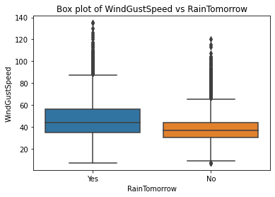

```python
# Boxplot of WindGustSpeed attribute vs target attribute RainTomorrow
sns.boxplot(y="WindGustSpeed", x="RainTomorrow", data=df)
plt.title("Box plot of WindGustSpeed vs RainTomorrow")
```

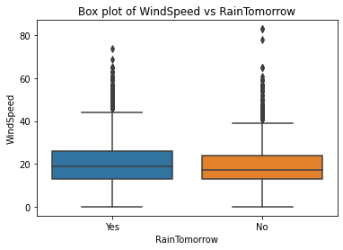

```python
# Boxplot of WindSpeed attribute vs target attribute RainTomorrow
sns.boxplot(y="WindSpeed", x="RainTomorrow", data=df)
plt.title("Box plot of WindSpeed vs RainTomorrow")
```

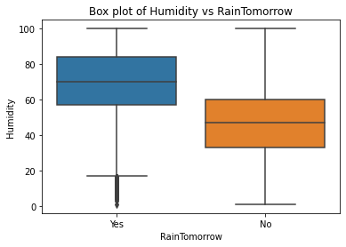

```python
# Boxplot of Humidity attribute vs target attribute RainTomorrow
sns.boxplot(y="Humidity", x="RainTomorrow", data=df)
plt.title("Box plot of Humidity vs RainTomorrow")
```

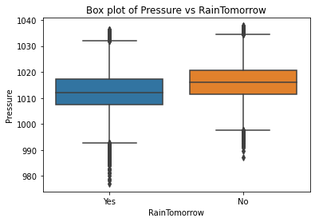

```python
# Boxplot of Pressure attribute vs target attribute RainTomorrow
sns.boxplot(y="Pressure", x="RainTomorrow", data=df)
plt.title("Box plot of Pressure vs RainTomorrow")
```

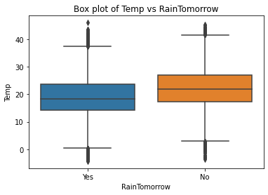

```python
# Boxplot of Temp attribute vs target attribute RainTomorrow
sns.boxplot(y="Temp", x="RainTomorrow", data=df)
plt.title("Box plot of Temp vs RainTomorrow")
```

```python
# Clipping the outliers for the below attributes according to the values present at the 5th and the 95th percentile
cols = ['MinTemp', 'MaxTemp', 'Rainfall', 'WindGustSpeed', 'WindSpeed', 'Humidity', 'Pressure', 'Temp']
df[cols] = df[cols].clip(lower=df[cols].quantile(0.05), upper=df[cols].quantile(0.95), axis=1)
```

#### 3) Checking highly correlated columns & distribution of the target attribute. Using the correlation plot to check the correlation between all the attributes in the dataset with target data 'RainTomorrow. We need convert categorical data into numerical i.e. Yes/No to 0/1.

```python
df['RainToday'] = df['RainToday'].map(dict(Yes=1, No=0))
df['RainTomorrow'] = df['RainTomorrow'].map(dict(Yes=1, No=0))
```

```python
test_df['RainToday'] = test_df['RainToday'].map(dict(Yes=1, No=0))
```

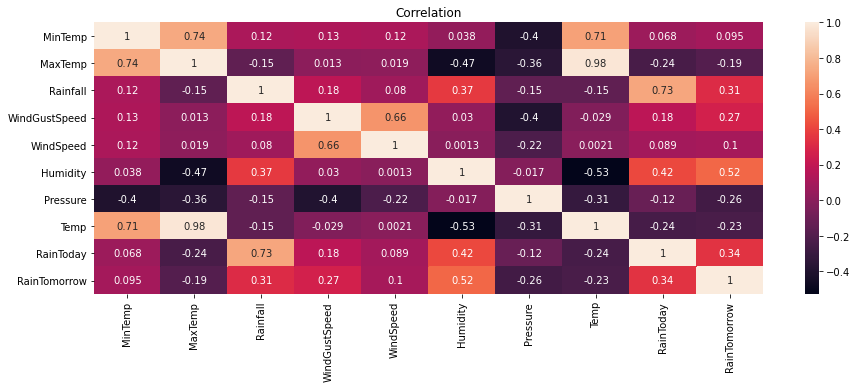

```python
# Ploting correlation matrix heatmap
plt.figure(figsize=(15,5))
plt.title("Correlation")
sns.heatmap(df.corr(),annot=True)
```

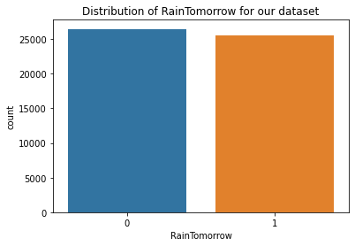

```python
# Countplot to check the distribution of labels in attribute - 'RainTommorow'
sns.countplot(x="RainTomorrow", data=df).set_title('Distribution of RainTomorrow for our dataset')
```

#### 4) Data Imputation

Checking for the total number of missing values present in both the training data and testing data.

```python
# Check total null values present for all attributes in training data
df.isnull().sum()
```

```
Location            0
MinTemp           284
MaxTemp           129
Rainfall          747
WindGustDir      3598
WindGustSpeed    3571
WindDir          1513
WindSpeed        1024
Humidity         1429
Pressure         5066
Temp             1063
RainToday         747
RainTomorrow        0
dtype: int64
```

```python
# Check total null values present for all attributes in testing data
test_df.isnull().sum()
```

```
ID                  0
Location            0
MinTemp            47
MaxTemp            18
Rainfall          161
WindGustDir       929
WindGustSpeed     920
WindDir           387
WindSpeed         261
Humidity          349
Pressure         1293
Temp              267
RainToday         161
dtype: int64
```

##### Imputing categorical attributes with mode values.

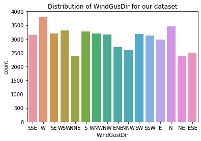

```python
# Distribution plot for 'WindGustDir' for training data
sns.countplot(x="WindGustDir", data=df).set_title('Distribution of WindGusDir for our dataset')
```

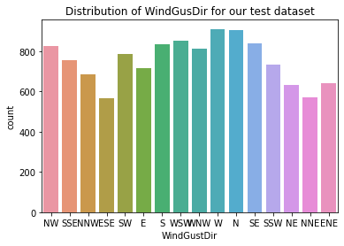

```python
# Distribution plot for 'WindGustDir' for testing data
sns.countplot(x="WindGustDir", data=test_df).set_title('Distribution of WindGusDir for our test dataset')
```

### Filling up all the missing values by mode values, plot shows mode value for 'WindGustDir' and 'WindDir' is West hence filling with the mode value 'W'. Similary, imputed the missing values of RainToday by 0 because for all the missing value days precipitation is 1mm.

```python
# Imputing missing values for 'WindGusDir' with mode value 'W' for both train and test data
df.WindGustDir = df.WindGustDir.fillna('W')
test_df.WindGustDir = test_df.WindGustDir.fillna('W')
```

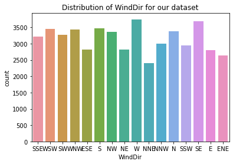

```python
# Distribution plot for 'WindDir' for training data
sns.countplot(x="WindDir", data=df).set_title('Distribution of WindDir for our dataset')
```

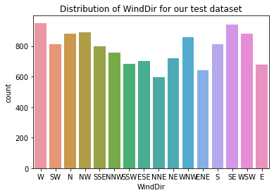

```python
# Distribution plot for 'WindDir' for testing data
sns.countplot(x="WindDir", data=test_df).set_title('Distribution of WindDir for our test dataset')
```

```python
# Imputing missing values for 'WindDir' with mode value 'W' for both train and test data
df.WindDir = df.WindDir.fillna('W')
test_df.WindDir = test_df.WindDir.fillna('W')
```

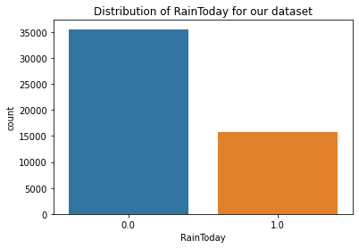

```python
# Distribution plot for 'RainToday' for training data
sns.countplot(x="RainToday", data=df).set_title('Distribution of RainToday for our dataset')
```

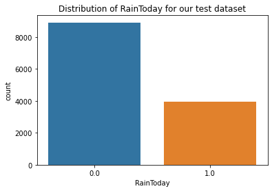

```python
# Distribution plot for 'RainToday' for testing data
sns.countplot(x="RainToday", data=test_df).set_title('Distribution of RainToday for our test dataset')
```

```python
# Imputing missing values for 'RainToday' with mode value '0' for both train and test data
df.RainToday = df.RainToday.fillna('0')
test_df.RainToday = test_df.RainToday.fillna('0')
```

#### Correlation matrix for correlation is greater than 0.7

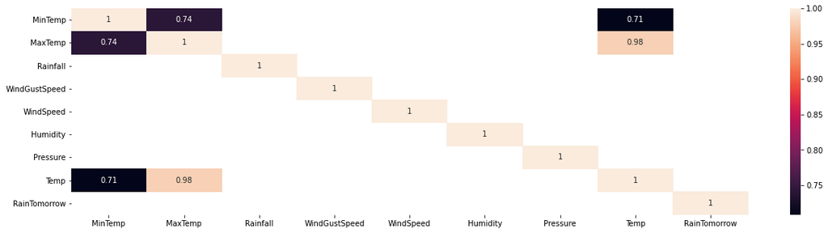

```python
#Below we plot a correlation matrix which has absolute correlation value greater than 0.7
plt.figure(figsize=(20,5))
sns.heatmap(df.corr()[abs(df.corr())>.7],annot=True);
```

#### 'MaxTemp' and 'Temp' have correlation vaue of 0.98 so imputing the missing values in MaxTemp with the Temp values.

```python
df['MaxTemp'] = df.apply(lambda row: row['Temp'] if np.isnan(row['MaxTemp']) else row['MaxTemp'],axis=1)
df.drop("Temp",inplace=True,axis=1)
```

```python
test_df['MaxTemp'] = test_df.apply(lambda row: row['Temp'] if np.isnan(row['MaxTemp']) else row['MaxTemp'],axis=1)
test_df.drop("Temp",inplace=True,axis=1)
```

#### Using fancyimpute package's MICE algorithm to impute all the remaining missing values present in all the numerical attributes

```python
# Implementing MICE imputer
MICE_imputer = IterativeImputer()
```

```python
# Imputing missing values for all the numerical attributes using MICE for the training dataset
df.iloc[:, [1,2,3,5,7,8,9]] = MICE_imputer.fit_transform(df.iloc[:, [1,2,3,5,7,8,9]])
```

```python
# Doing MICE imputation for testing dataset
test_df.iloc[:, [2,3,4,6,8,9,10]] = MICE_imputer.fit_transform(test_df.iloc[:, [2,3,4,6,8,9,10]])
```

```python
# Checking final sum of missing values for training data
df.isna().sum().sum()
```

```
0
```

```python
# Checking final sum of missing values for testing data
test_df.isna().sum().sum()
```

```
0
```

## K-Means Clustering Model

```python
# Creating a copy of pre-processed train and test data that we will be using to implement K-Means
train_df_kmeans = df.copy()
test_df_kmeans = test_df.copy()
```

```python
#Dropping all the categorical columns, 'RainToday' from the train and test data and dropping 'ID' from test data
train_df_kmeans.drop(["Location",'WindDir','WindGustDir','RainToday'],axis=1,inplace=True)
test_df_kmeans.drop(["Location",'WindDir','WindGustDir','RainToday', 'ID'],axis=1,inplace=True)
```

```python
# Train-test split
X = train_df_kmeans.drop('RainTomorrow', axis=1)
```

```python
# Train-test split
y = train_df_kmeans['RainTomorrow']
```

```python
# Creating Train-test split
X_train, X_test, y_train, y_test = train_test_split(X, y, test_size=0.1, random_state=0)
```

```python
# Using MinMax scalar
min_max_scaler_kmeans = preprocessing.MinMaxScaler()
```

```python
# Scaling train data
X_train=min_max_scaler_kmeans.fit_transform(X_train)
```

```python
# Scaling validation data
X_test=min_max_scaler_kmeans.transform(X_test)
```

```python
# Scaling test data
test_df_kmeans=min_max_scaler_kmeans.transform(test_df_kmeans)
```

```python
# Implementing Kmeans model with 2 clusters
kmeans_model = KMeans(n_clusters=2,random_state=0)
```

#### Hyper-parameter tuning using GridSearch.

```python
# Performing grid search to find the best hyper-parameters
param_grid_kmeans = {
              'n_init': [10,20,25,50],
              'max_iter': [10,20,50,100],
              }

# Using 10 fold cross validation and evaluation metric as Recall
grid_kmeans = GridSearchCV(kmeans_model, param_grid_kmeans, cv=10, scoring='recall')

# Fitting Kmeans model
grid_kmeans.fit(X_train, y_train)
```

```
GridSearchCV(cv=10, estimator=KMeans(n_clusters=2, random_state=0),
             param_grid={'max_iter': [10, 20, 50, 100],
                         'n_init': [10, 20, 25, 50]},
             scoring='recall')
```

```python
# Printing the best hyper-parameters obtained from the grid search
grid_kmeans.best_params_
```

```
{'max_iter': 20, 'n_init': 25}
```

#### Classification reports indicates our K-Means model performs similarly well on the training and testing data. Recall value is 0.54 which indicates accuracy, model is able to predict correctly 54% which is not good.

```python
# Printing classification report for predictions made by model on training dataset
print(classification_report(grid_kmeans.predict(X_train),y_train))
```

```
              precision    recall  f1-score   support

           0       0.54      0.56      0.55     22898
           1       0.56      0.54      0.55     23882

    accuracy                           0.55     46780
   macro avg       0.55      0.55      0.55     46780
weighted avg       0.55      0.55      0.55     46780
```

```python
# Printing classification report for predictions made by model on validation dataset
print(classification_report(grid_kmeans.predict(X_test),y_test))
```

```
              precision    recall  f1-score   support

           0       0.54      0.57      0.55      2530
           1       0.57      0.54      0.55      2668

    accuracy                           0.55      5198
   macro avg       0.55      0.55      0.55      5198
weighted avg       0.55      0.55      0.55      5198
```

```python
# Predicting rain forecast labels for test dataset
test_prediction_kmeans = grid_kmeans.predict(test_df_kmeans)
```

## Decision Tree

```python
# Creating a copy of pre-processed train and test data that we will be using to implement Decision tree model
train_df_dt = df.copy()
test_df_dt = test_df.copy()
```

```python
# Converting categorical attribute 'Location' into numerical attribute using One-Hot encoding and then dropping the original 'Location' attribute. Doing the same for both train and test data
train_df_dt = pd.concat([train_df_dt,pd.get_dummies(train_df_dt['Location'], prefix='Location')],axis=1)
train_df_dt.drop(['Location'],axis=1, inplace=True)
test_df_dt = pd.concat([test_df_dt,pd.get_dummies(test_df_dt['Location'], prefix='Location')],axis=1)
test_df_dt.drop(['Location'],axis=1, inplace=True)

# Converting categorical attribute 'WindGustDir' into numerical attribute using One-Hot encoding and then dropping the original 'WindGustDir' attribute. Doing the same for both train and test data
train_df_dt = pd.concat([train_df_dt,pd.get_dummies(train_df_dt['WindGustDir'], prefix='WindGustDir')],axis=1)
train_df_dt.drop(['WindGustDir'],axis=1, inplace=True)
test_df_dt = pd.concat([test_df_dt,pd.get_dummies(test_df_dt['WindGustDir'], prefix='WindGustDir')],axis=1)
test_df_dt.drop(['WindGustDir'],axis=1, inplace=True)

# Converting categorical attribute 'WindDir' into numerical attribute using One-Hot encoding and then dropping the original 'WindDir' attribute. Doing the same for both train and test data
train_df_dt = pd.concat([train_df_dt,pd.get_dummies(train_df_dt['WindDir'], prefix='WindDir')],axis=1)
train_df_dt.drop(['WindDir'],axis=1, inplace=True)
test_df_dt = pd.concat([test_df_dt,pd.get_dummies(test_df_dt['WindDir'], prefix='WindDir')],axis=1)
test_df_dt.drop(['WindDir'],axis=1, inplace=True)
```

```python
# Building model for decision tree algorithm
dt_clf=DecisionTreeClassifier(random_state=0)
```

```python
# Creating the train validation split
X = train_df_dt.drop('RainTomorrow', axis=1)

y = train_df_dt['RainTomorrow']

X_train, X_test, y_train, y_test = train_test_split(X, y, test_size=0.1, random_state=0)
```

#### Hyper-paramater tuning using GridSearch:

```python
# Using grid search for hyper-parameter tuning
param_grid_dt = { 'criterion':['gini','entropy'],
              'min_samples_split':[25,50,100,200],
              'max_depth': [5,10,20,25,30],
              'min_samples_leaf': [1,3,5,10,20],
              'max_leaf_nodes': [2,5,10,20,40]}

# Using 10 folds cross validation in the grid search and evaluation metric as recall
grid_dt = GridSearchCV(dt_clf, param_grid_dt, cv=10, scoring='recall')

# Fitting the decision tree model on training data
grid_dt.fit(X_train, y_train)
```

```
GridSearchCV(cv=10, estimator=DecisionTreeClassifier(random_state=0),
             param_grid={'criterion': ['gini', 'entropy'],
                         'max_depth': [5, 10, 20, 25, 30],
                         'max_leaf_nodes': [2, 5, 10, 20, 40],
                         'min_samples_leaf': [1, 3, 5, 10, 20],
                         'min_samples_split': [25, 50, 100, 200]},
             scoring='recall')
```

#### The recall value is 0.71 which indicates that our model 71% accurate which is better than Kmeans.

```python
# Printing classification report for predictions made by model on training dataset
print(classification_report(grid_dt.predict(X_train),y_train))
```

```
              precision    recall  f1-score   support

           0       0.69      0.75      0.72     21673
           1       0.77      0.70      0.73     25107

    accuracy                           0.73     46780
   macro avg       0.73      0.73      0.73     46780
weighted avg       0.73      0.73      0.73     46780
```

```python
# Printing classification report for predictions made by model on validation dataset
print(classification_report(grid_dt.predict(X_test),y_test))
```

```
              precision    recall  f1-score   support

           0       0.70      0.76      0.73      2463
           1       0.77      0.71      0.73      2735

    accuracy                           0.73      5198
   macro avg       0.73      0.73      0.73      5198
weighted avg       0.73      0.73      0.73      5198
```

#### Generating the AUC-ROC curve for the Decision tree model

- The AUC-ROC score is 80% which means that the model is not random.

```
No Skill: ROC AUC=0.500
Decision Tree: ROC AUC=0.800
```

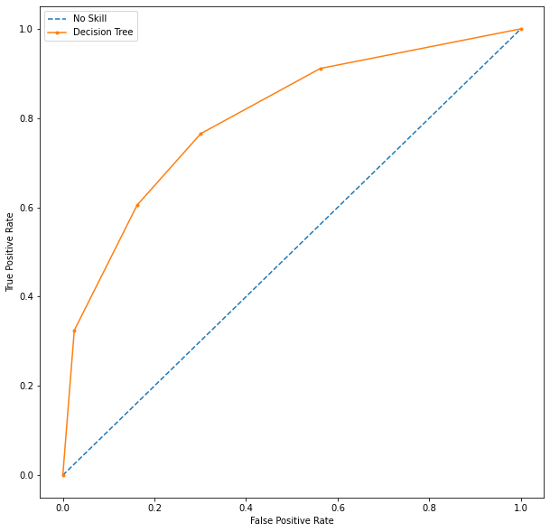

```python
ns_probs = [0 for _ in range(len(y_test))]
dt_probs = grid_dt.predict_proba(X_test)
dt_probs = dt_probs[:, 1]
ns_auc = roc_auc_score(y_test, ns_probs)
dt_auc = roc_auc_score(y_test, dt_probs)
print('No Skill: ROC AUC=%.3f' % (ns_auc))
print('Decision Tree: ROC AUC=%.3f' % (dt_auc))
ns_fpr, ns_tpr, _ = roc_curve(y_test, ns_probs)
dt_fpr, dt_tpr, _ = roc_curve(y_test, dt_probs)
plt.figure(figsize=(10,10))
plt.plot(ns_fpr, ns_tpr, linestyle='--', label='No Skill')
plt.plot(dt_fpr, dt_tpr, marker='.', label='Decision Tree')
# axis labels
plt.xlabel('False Positive Rate')
plt.ylabel('True Positive Rate')
# show the legend
plt.legend()
# show the plot
plt.show()
```

```python
# Dropping the 'ID' attribute from the testing data
test_df_dt= test_df_dt.drop('ID', axis=1)
```

```python
# Predicting rain forecast labels for test dataset
test_prediction_dt = grid_dt.predict(test_df_dt)
```